# 14. Line names and data

There are several pieces of information maintained for each line. Most are stored either in the new web site, or in the FileMaker Lines table, or both. There is duplication between them because Planeteria didn’t talk to me before implementing their system.

## Lines table in FileMaker

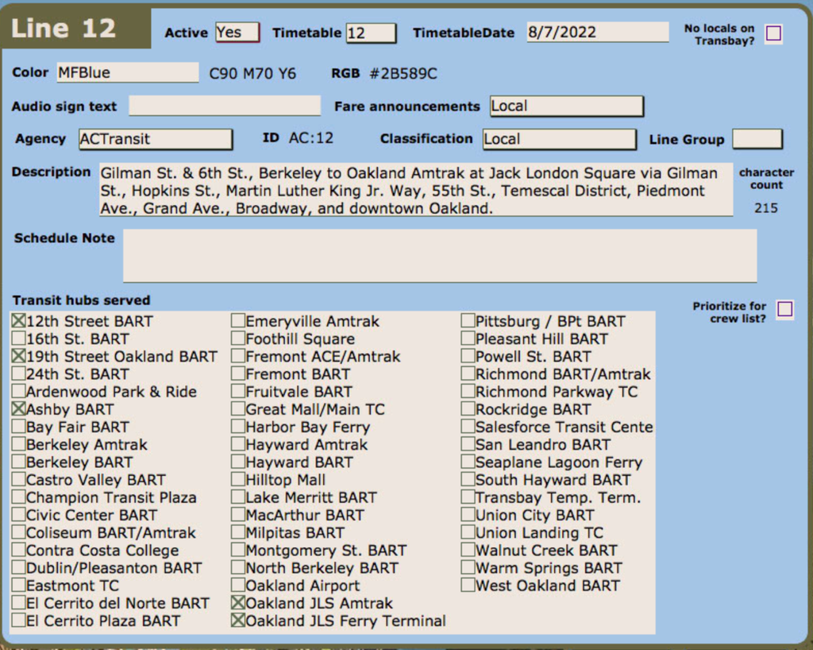

## Web site entry

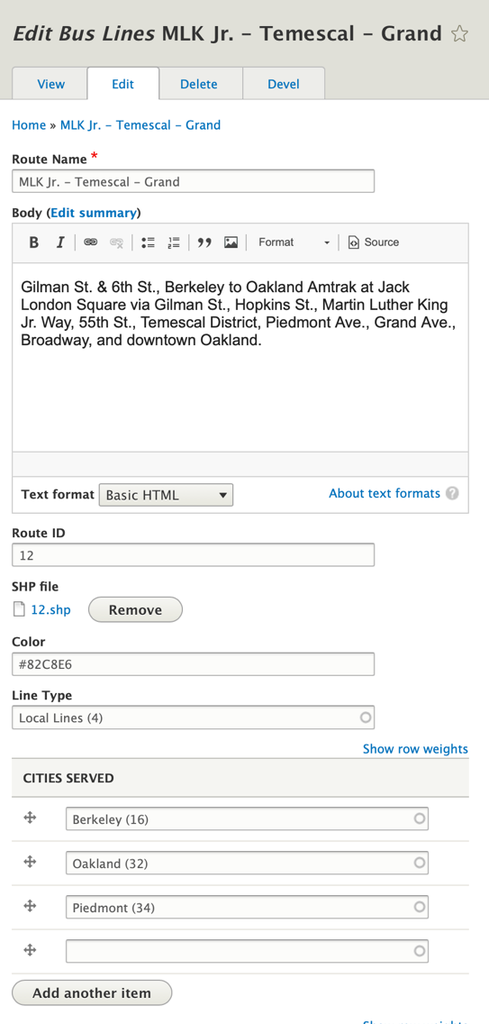

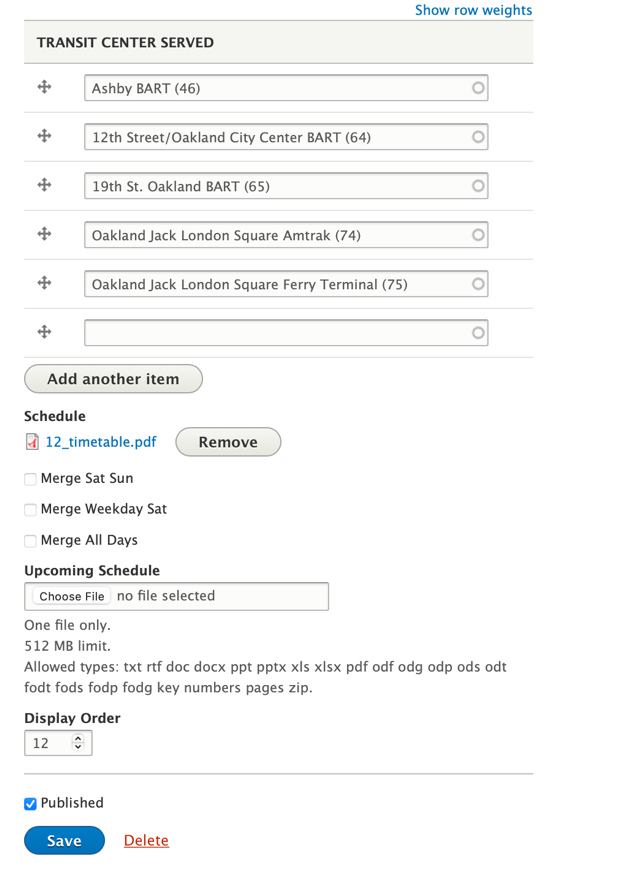

I think some of these entries on the web site may be obsolete and not used on the web site any more. I know the timetable PDF isn’t used, and I think the color isn’t either. I’m not really sure about the others. A number of them ought to be derived from Hastus rather than entered manually (that’s true of the “Active” entry in the FileMaker Lines table as well).

# Line name

There is a 32-character line name that was developed for BusTime. At the time Planning delivers service specifications to Scheduling, they should also provide them to Communications so that this name can be updated. The completed name should then be given to Scheduling for inclusion in Hastus.

I keep these in an Excel spreadsheet called “Meager Line Descriptions 2022_06_09.xlsx” in the folder “PubInfSys - Documents/Colors, headsigns, numbers, info coordination/Line names”. (“Meager” because 32 characters is pretty poor.) I don’t think the web site picks this up from Hastus, although it ought to.

# Line color

Although the new system map means lines can have multiple colors if there are branches with different frequencies, most lines use a single color and it’s convenient to use that color most places the lines are. The colors are, corresponding to the system map:

| LongColorName | RGB |
| --- | --- |
| High Frequency | #A30D11 |
| Irregular Brown | #BC8E2D |
| Low Frequency | #07B5D0 |
| Medium Frequency | #2B589C |
| Other Lavender | #9791C6 |
| Tempo Purple | #782B84 |
| Unspecified Gray | #595959 |

For each line, there’s an entry in the Lines table in FileMaker. The color for each line should also be provided to Scheduling for inclusion in Hastus.

# Line classification / Line type

This distinguishes local, Transbay, school, Early Bird, etc. lines. We haven’t always been consistent about line types (is 800 Transbay or All Nighter, or its own “Transbay All Nighter” category? Are 200-series lines local? Is Early Bird, or Rapid, or Tempo a category?). I’m honestly not sure how this works on the web site, although I think it would have been taken from the old web site’s line description categories, which came from me originally.

Planning has another set of line categories (including things like “Trunk” and “Crosstown”) that we don’t use. The frequency breakdown on the system map is another categorization.

# Line description

There is a longer line description which is used on the web site and on the TIDs. Unfortunately the web site people just copied and pasted them off the old web site and now the same data has to be updated both places.

The version on the TIDs comes out of the Lines table and is generated from “actium.pl linedescrip -s signup”. It stores InDesign Tagged Text files in the “line_descrip” folder in the signup folder. These should be copied to Creative Cloud Files/TIDs/Org/AC Transit/generated

# Transit Hubs served

Each line serves a number of transit hubs. This is used to determine the InDesign files for “actium.pl linedescrip” and also is displayed on the web site.

This is another thing that I had set in my database but now has to be done twice, once in the database so that actium.pl linedescrip will work, and once on the web site. It may be easier just to maintain these descriptions manually in InDesign than keep up the actium.pl linedescrip program.

I had planned, once upon a time, to set up a table of points of interest, including transit hubs, and associate stops and points of interest. Lines frequently change routings and end up serving different stops, but stops don’t move and points of interest rarely do, so that association would remain stable. Thus the list of lines served by each transit hub, or school, or other point of interest would be easily determined from which stops they served, and would almost certainly be valid for a long time.

# Cities served

This is entered on the web page. This is one of those things that should never touch a person at all, because the system should know which stops a line serves, and which city each stop is in. (Ideally it would use my updated list of cities and stops which includes places like San Lorenzo and Castro Valley, rather than just “Alameda County,” but that’s a detail).

Nonetheless, Planeteria set it up to be entered manually.

# More Lines table fields

## TimetableDate

This is used by both the at-stop schedule programs and the printable timetable programs.

## Timetable

This is a reference to the separate Timetable table; see the document on the printable timetable system.

## Audio Sign Text and Fare announcements

To be discussed in the “Cleverworks route audio and attributes” document.

# More web site fields

There are a number of web site fields that are there, but that I’ve never touched – the “merge” fields (this should definitely be determined from Hastus data rather than manually), the shape file, the display order. Basically, if Planeteria touched it, it’s probably wrong in some significant way.